# FIRST HOMEWORK: UNSUPERVISED LEARNING

# 7 Clustering

The process of clustering involves grouping the population or data points into a number of groups so that the data points within each group are more similar to one another than the data points within other groups. Simply said, the goal is to sort into clusters any groups of people who share similar characteristics. There are several methods of clustering; there are some along the lines of k-means, k-means with mahalanobis distance, PAM…

## 7.1 METHOD 1: K-means.

For example, K-means clustering algorithms assign similar data points into groups, where the K value represents the size of the grouping and granularity. This technique is helpful for market segmentation, image compression, etc.

K-means works in the following way:

- 1. Choose the number of clusters K.
- 2. Select randomly K points,which will be the initial centroids of the clusters. A centroid is imaginary or real location representing the center of the cluster. Every data point is allocated to each of the clusters through reducing the in-cluster sum of squares.
- 3. Assign each point to the nearest centroid. This creates the K clusters.
- 4. If the centroids have changed, go back to step 3; otherwise the algorithm ends.

```r
# It is a must to transform all the variables to numeric, since clustering only works
# with these kind of variables. Factor variables are excluded.
data_clustering <- final_dataset[c(3, 6:22)]
data_clustering <- as.data.frame(sapply(data_clustering, as.numeric))
```

### 7.1.1 STEP 1: Scale data.

```r
# The reason why data is scaled is stated in the first step of PCA. The same
# applies for clustering. Data is scaled or standardized so that each one of them
# contributes equally to the analysis.
X <- scale(data_clustering)
```

### 7.1.2 STEP 2: Run k-means by choosing a random number of clusters.

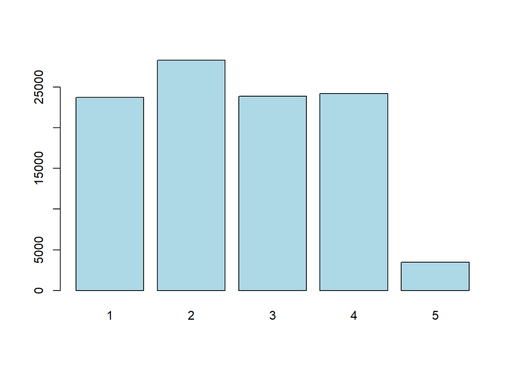

```r
# K-means is performed using the function 'kmeans(x, centers, nstart)', where 'x'
# is a numeric matrix of data; 'centers', which is either the number of clusters
# or a set of initial distinct cluster centers; and 'nstart', which are the random
# sets that should be chosen in case 'centers' is a number.
# In this case, 'x' is the scaled data; 'centers' was set to the random number
# of 5; and 'nstart' was set to 25 (an exceedingly high number must no be considered
# due to the high number of observations of the dataset).
fit = kmeans(X, centers=5, nstart=25)
groups = fit$cluster
barplot(table(groups), col="#ADD8E6")
```

```r
# As observed, 5 centers show an unbalanced classification.
```

### 7.1.3 STEP 3: Visualize and understand the centers.

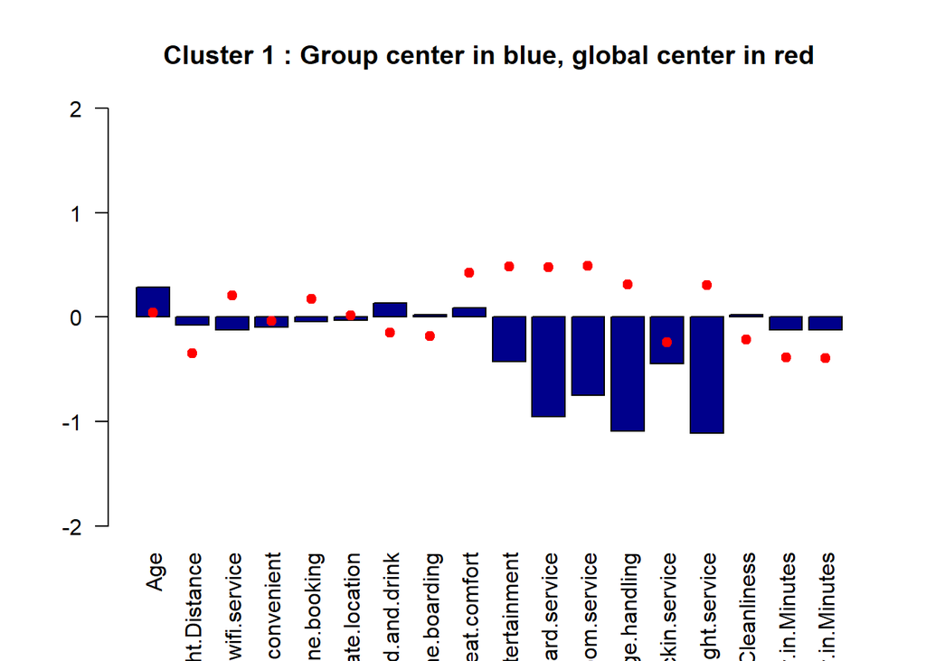

```r
centers = fit$centers

# Cluster 1.
bar1=barplot(centers[1,], las=2, col="darkblue", ylim=c(-2,2), main=paste("Cluster", 1,": Group center in blue, global center in red"))
points(bar1,y=apply(X, 2, quantile, 0.50),col="red",pch=19)
```

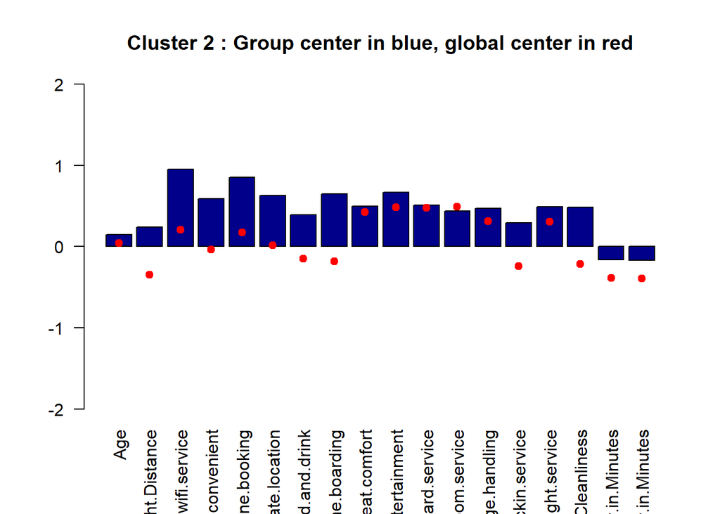

```r
# Cluster 2.
bar2=barplot(centers[2,], las=2, col="darkblue", ylim=c(-2,2), main=paste("Cluster", 2,": Group center in blue, global center in red"))
points(bar2,y=apply(X, 2, quantile, 0.50),col="red",pch=19)
```

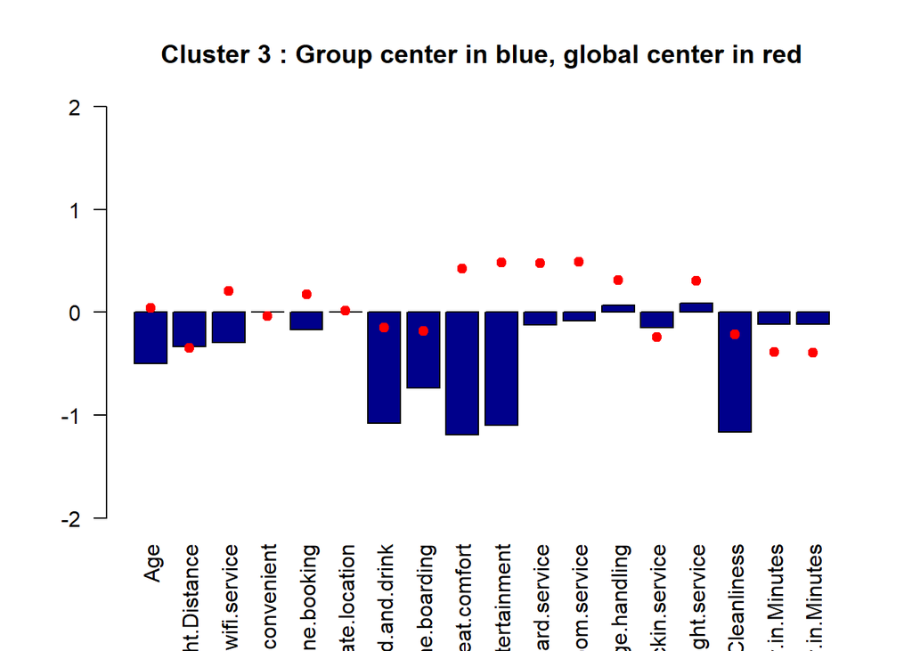

```r
# Cluster 3.
bar3=barplot(centers[3,], las=2, col="darkblue", ylim=c(-2,2), main=paste("Cluster", 3,": Group center in blue, global center in red"))
points(bar3,y=apply(X, 2, quantile, 0.50),col="red",pch=19)
```

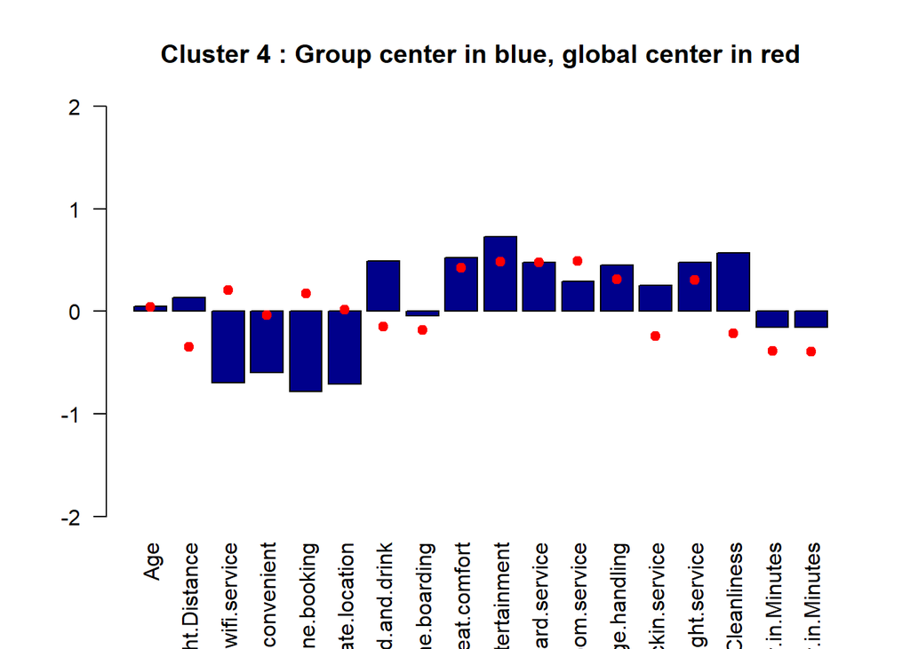

```r
# Cluster 4.
bar4=barplot(centers[4,], las=2, col="darkblue", ylim=c(-2,2), main=paste("Cluster", 4,": Group center in blue, global center in red"))
points(bar4,y=apply(X, 2, quantile, 0.50),col="red",pch=19)
```

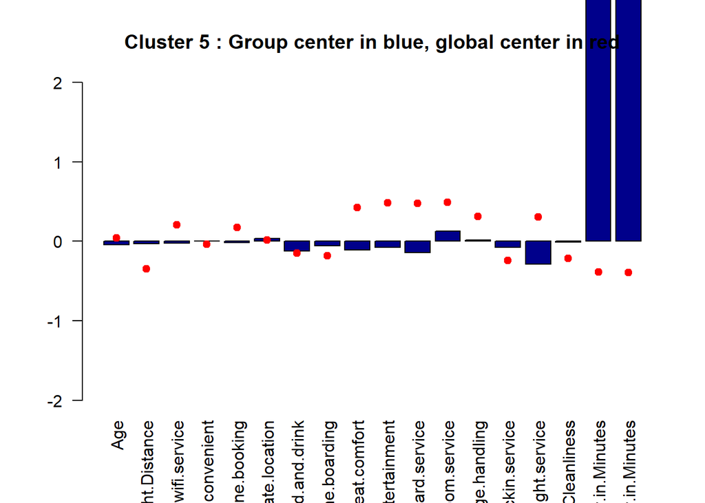

```r
# Cluster 5.
bar5=barplot(centers[5,], las=2, col="darkblue", ylim=c(-2,2), main=paste("Cluster", 5,": Group center in blue, global center in red"))
points(bar5,y=apply(X, 2, quantile, 0.50),col="red",pch=19)
```

### 7.1.4 STEP 4: Cluspot.

The main goal of the clusplot is to create a plot visualizing a clustering of the data. All observation are represented by points in the plot, using principal components or multidimensional scaling.

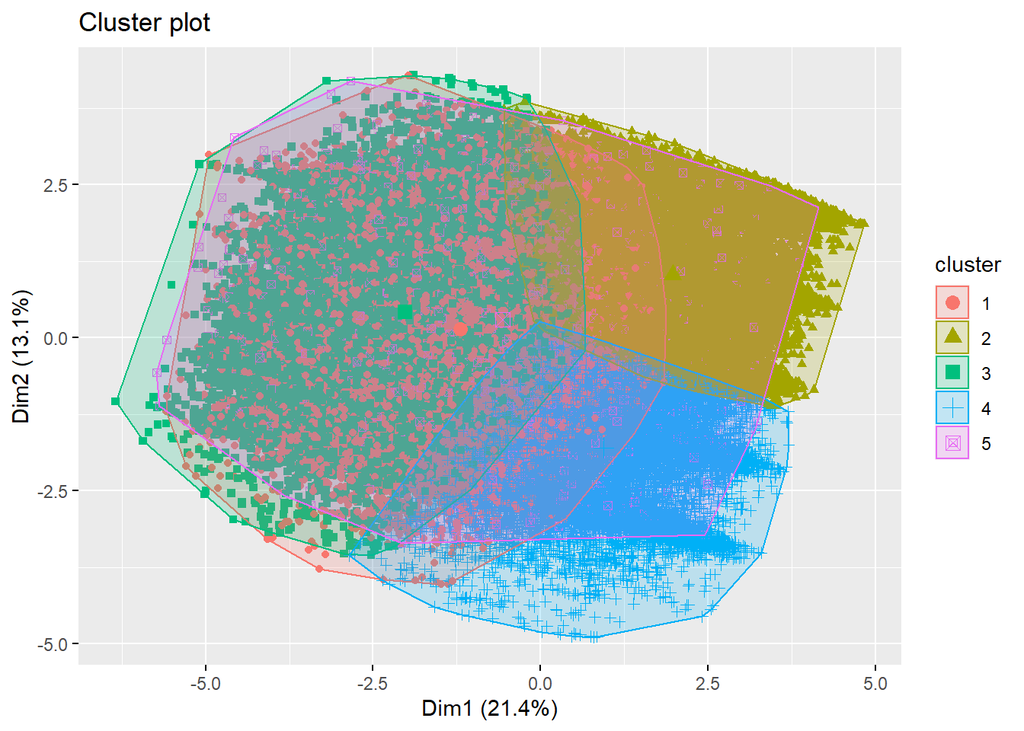

```r
fviz_cluster(fit, X, geom = c("point"))
```

```r
# As observed, 5 centers show an unbalanced classification. In the next step,
# the best number of clusters will be found.
```

### 7.1.5 STEP 5: Select the best number of clusters.

As previously stated in step 4, five centers are not enough. Thus, the best number of clusters will be found using the elbow method.

In the Elbow method, we are actually varying the number of clusters (K) from 1 – 10. For each value of K, we are calculating WSS. This is the sum of squared distance between each point and the centroid in a cluster. When we plot the WSS with the K value, the plot looks like an Elbow. As the number of clusters increases, the WSS value will start to decrease. WSS value is largest when K = 1. When we analyze the graph we can see that the graph will rapidly change at a point and thus creating an elbow shape. From this point, the graph starts to move almost parallel to the X-axis. The K value corresponding to this point is the optimal K value or an optimal number of clusters.

```r
evaluation = data.frame(cluster = 1:10, WSS = 0)
for(i in 1:10){
  fit = kmeans(X,
               centers = evaluation$cluster[i],
               nstart = 25)
  evaluation$WSS[i] = sum(X-fit$centers[fit$cluster,]^2)
}
```

### 7.1.6 STEP 6: Visualize the results.

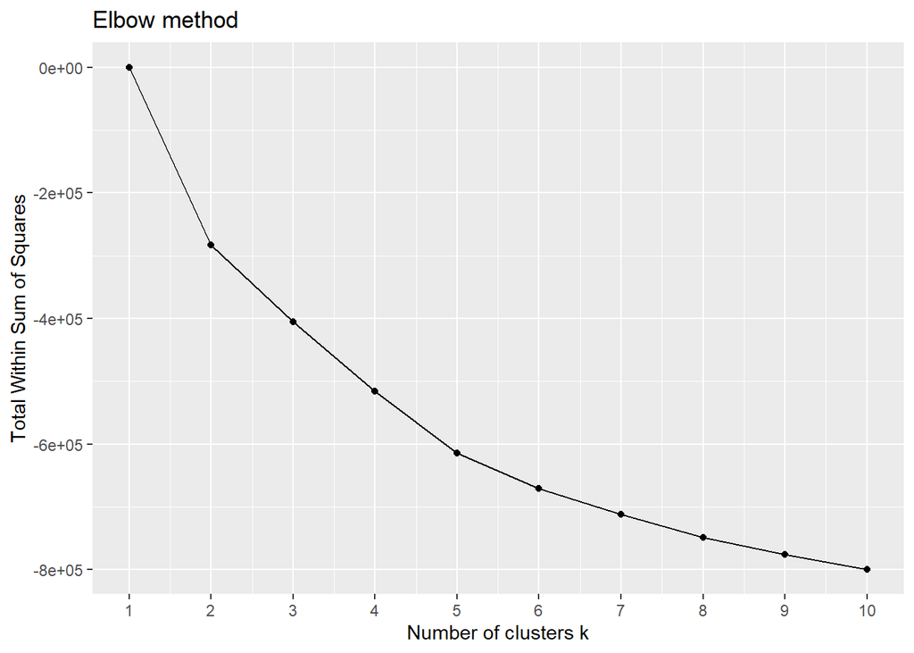

```r
ggplot(evaluation) + aes(x = cluster, y = WSS) +
  geom_point() + geom_line() +
  scale_x_continuous(breaks = 1:10) +
  xlab('Number of clusters k') +
  ylab('Total Within Sum of Squares') +
  labs(title = 'Elbow method')
```

```r
# Ergo, with 2 centers our data can be properly grouped.
```

### 7.1.7 STEP 7: Perform clustering with the best number of clusters.

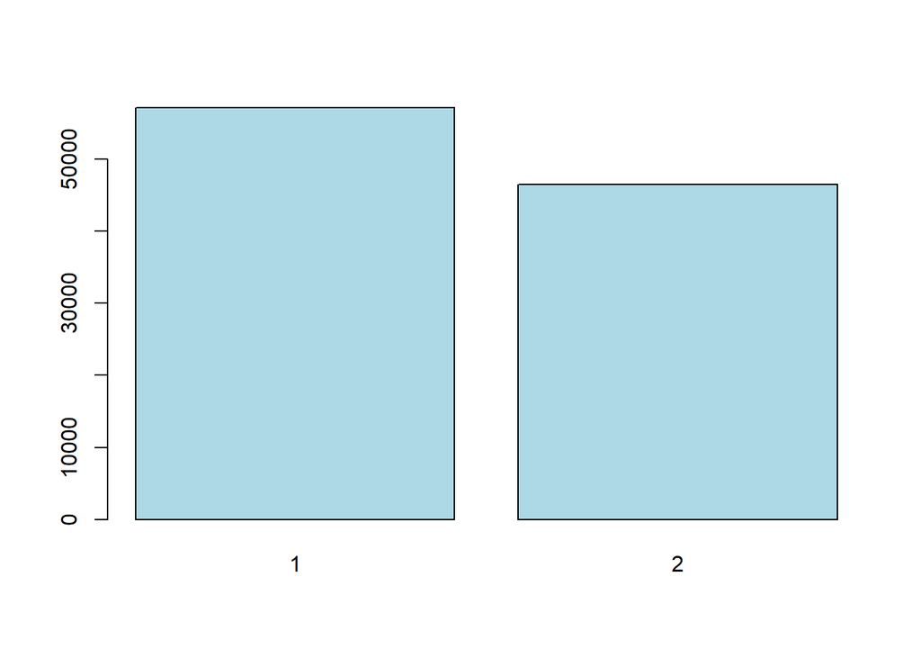

```r
fit = kmeans(X, centers = 2, nstart = 25)

# Is the classification more balanced than before?
groups = fit$cluster
barplot(table(groups), col="#ADD8E6")
```

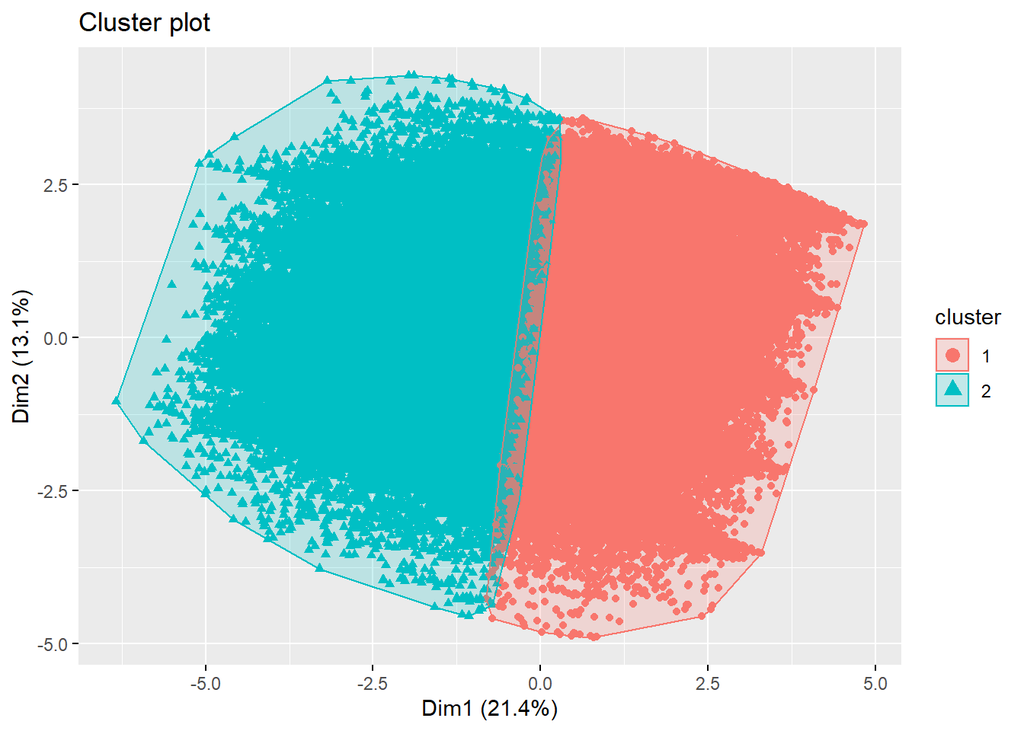

```r
# The clusplot can also be checked, observing that, indeed, a more balanced
# classification is obtained with the number of clusters equal to 2.
fviz_cluster(fit, X, geom = c('point'))
```

## 7.2 METHOD 2: K-means with Mahalanobis distance.

By default k-means uses the Euclidean distance; that is, it does not consider correlations between variables. If it is desired to incorporate these correlations, then the Mahalanobis distance may be useful.

### 7.2.1 STEP 1: Compute the Mahalanobis distance.

```r
# Prepare the data to be used in the process.
data_clustering2 <- final_dataset[c(3, 6:22)]
data_clustering2 <- as.data.frame(sapply(data_clustering2, as.numeric))
S_x <- cov(data_clustering2)
iS <- solve(S_x)
e <- eigen(iS)
V <- e$vectors
B <- V %*% diag(sqrt(e$values)) %*% t(V)
Xtil <- scale(data_clustering2,scale = FALSE)
dataS <- Xtil %*% B
```

### 7.2.2 STEP 2: K-means with a random number of clusters assuming an elliptic distribution.

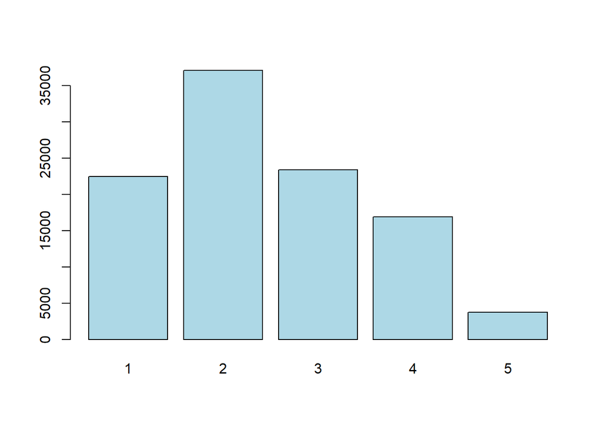

```r
# In this case, the random number of 5 was chosen. Note that this is totally of
# our choice. It could have been 6...or even 10.
fit.mahalanobis = kmeans(dataS, centers=5, nstart=25)
groups2 = fit.mahalanobis$cluster
barplot(table(groups2), col="#ADD8E6")
```

```r
# As observed, 5 centers show an unbalanced classification.
```

### 7.2.3 STEP 3: Visualize and understand the centers.

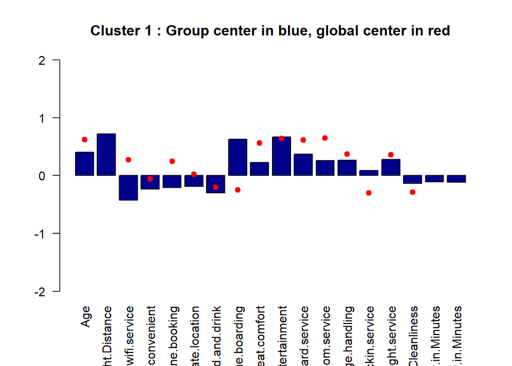

```r
centers2 = fit.mahalanobis$centers
colnames(centers2)=colnames(Xtil)

# Cluster 1.
bar1=barplot(centers2[1,], las=2, col="darkblue", ylim=c(-2,2), main=paste("Cluster", 1,": Group center in blue, global center in red"))
points(bar1,y=apply(Xtil, 2, quantile, 0.50),col="red",pch=19)
```

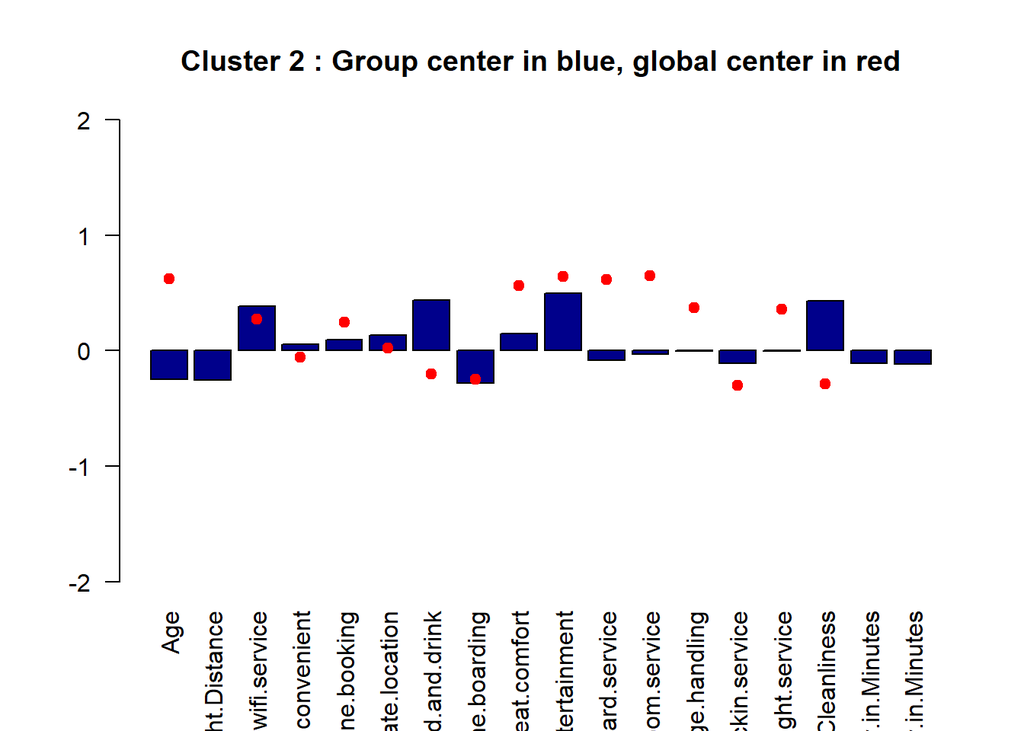

```r
# Cluster 2.
bar2=barplot(centers2[2,], las=2, col="darkblue", ylim=c(-2,2), main=paste("Cluster", 2,": Group center in blue, global center in red"))
points(bar2,y=apply(Xtil, 2, quantile, 0.50),col="red",pch=19)
```

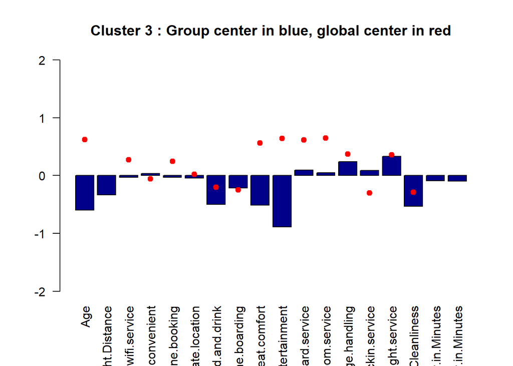

```r
# Cluster 3.
bar3=barplot(centers2[3,], las=2, col="darkblue", ylim=c(-2,2), main=paste("Cluster", 3,": Group center in blue, global center in red"))
points(bar3,y=apply(Xtil, 2, quantile, 0.50),col="red",pch=19)
```

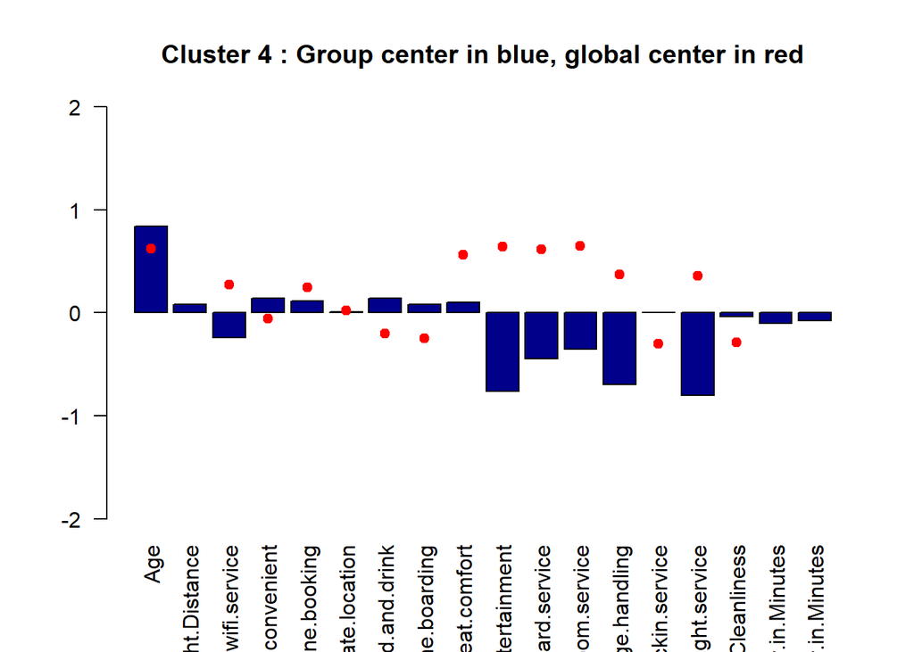

```r
# Cluster 4.
bar4=barplot(centers2[4,], las=2, col="darkblue", ylim=c(-2,2), main=paste("Cluster", 4,": Group center in blue, global center in red"))
points(bar4,y=apply(Xtil, 2, quantile, 0.50),col="red",pch=19)
```

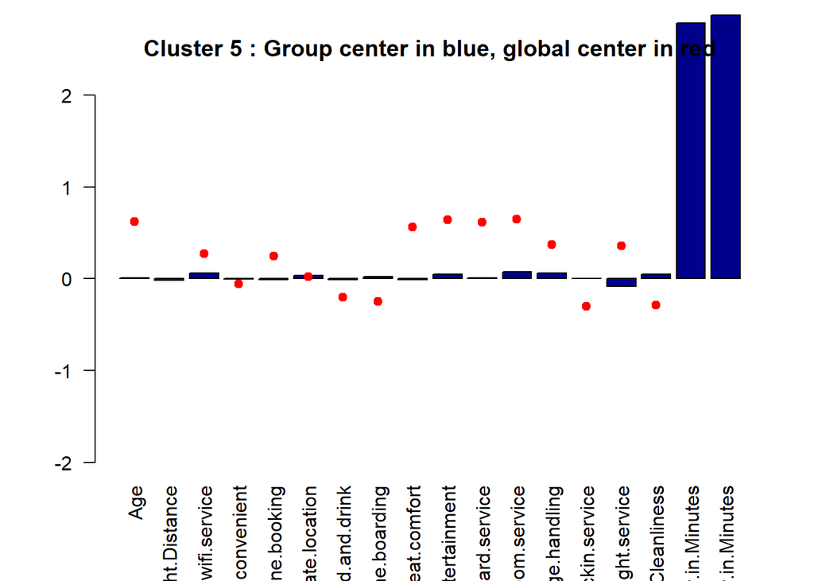

```r
# Cluster 5.
bar5=barplot(centers2[5,], las=2, col="darkblue", ylim=c(-2,2), main=paste("Cluster", 5,": Group center in blue, global center in red"))
points(bar5,y=apply(Xtil, 2, quantile, 0.50),col="red",pch=19)
```

### 7.2.4 STEP 4: Cluspot.

The main goal of the clusplot is to create a plot visualizing a clustering of the data. All observation are represented by points in the plot, using principal components or multidimensional scaling.

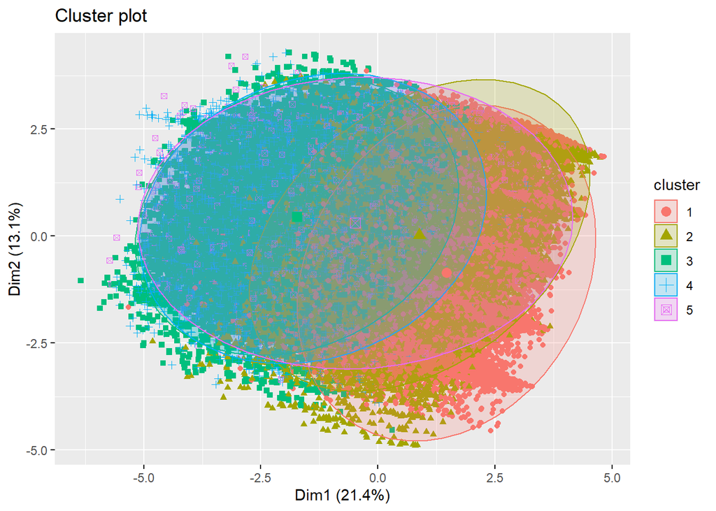

```r
fviz_cluster(fit.mahalanobis, Xtil, geom = c("point"), ellipse.type = 'norm')
```

```r
# As observed, 5 centers show an unbalanced classification. In the next step,
# the best number of clusters will be found.
```

### 7.2.5 STEP 5: Select the best number of clusters.

As previously stated in step 4, five centers are not enough. Thus, the best number of clusters will be found using the so-called elbow method (already explained how it works in method 1).

```r
evaluation = data.frame(cluster = 1:10, WSS = 0)
for(i in 1:10){
  fit.mahalanobis = kmeans(Xtil,
               centers = evaluation$cluster[i],
               nstart = 25)
  evaluation$WSS[i] = sum(Xtil-fit.mahalanobis$centers[fit.mahalanobis$cluster,]^2)
}
```

### 7.2.6 STEP 6: Visualize the results.

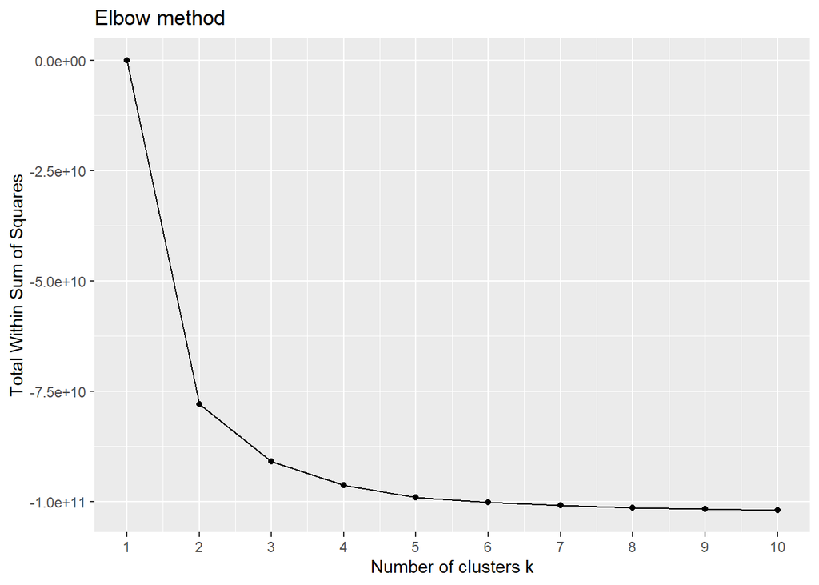

```r
ggplot(evaluation) + aes(x = cluster, y = WSS) +
  geom_point() + geom_line() +
  scale_x_continuous(breaks = 1:10) +
  xlab('Number of clusters k') +
  ylab('Total Within Sum of Squares') +
  labs(title = 'Elbow method')
```

```r
# Ergo, with 2 centers our data can be properly grouped. It is worth mentioning
# that this elbow method is somehow easier to interpret. That is, in this case
# one can better identify the number of clusters that best fits our model.
```

### 7.2.7 STEP 7: Perform clustering with the best number of clusters.

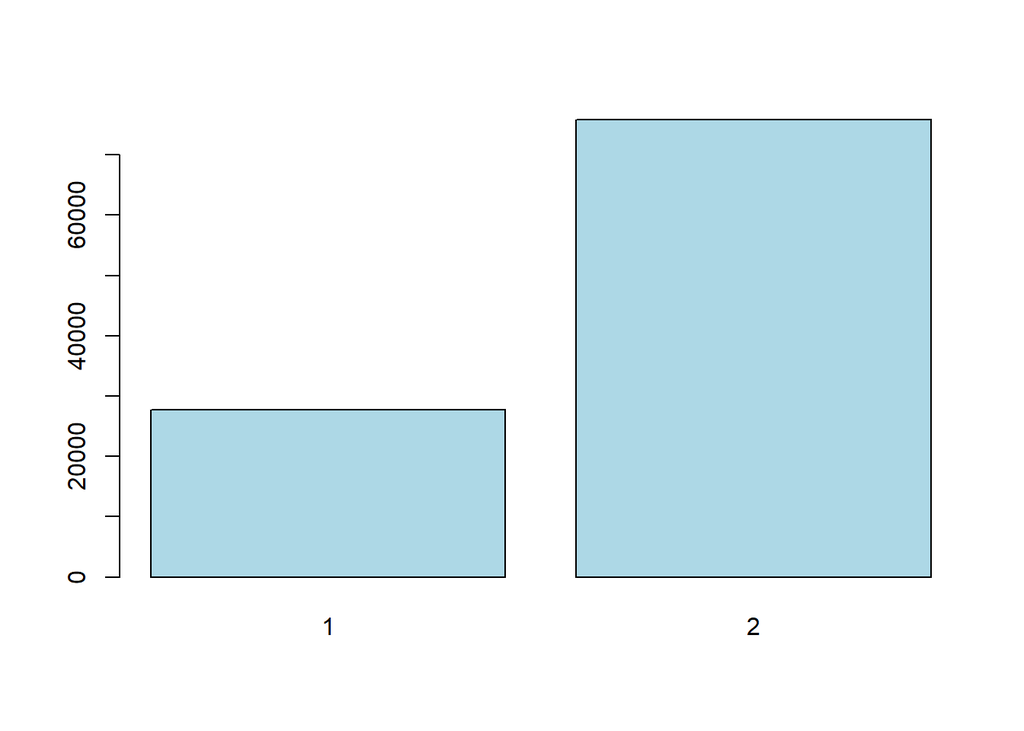

```r
fit.mahalanobis = kmeans(Xtil, centers = 2, nstart = 25)

# Is the classification more balanced than before?
groups2 = fit.mahalanobis$cluster
barplot(table(groups2), col="#ADD8E6")
```

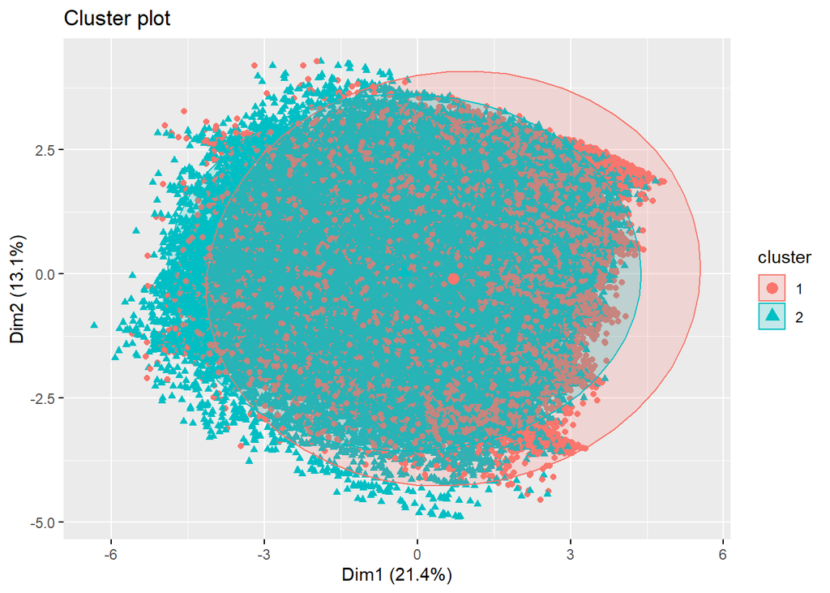

```r
# The clusplot can also be checked, observing that, in this case, a more balanced
# classification is NOT obtained with the number of clusters equal to 2.
fviz_cluster(fit.mahalanobis, Xtil, geom = c("point"), ellipse.type = 'norm')
```

## 7.3 How similar are the clusters?

So that the similarity of these methods can be checked, the adjusted rand index is used. The Adjusted Rand score is used to determine whether two cluster results are similar to each other. It calculates a similarity between two cluster results by taking all points identified within the same cluster.

```r
# Apply 'adjustedRandIndex()' function.
adjustedRandIndex(fit$cluster, fit.mahalanobis$cluster)
```

```
## [1] 0.007607172
```

# 8 Final comments.

Before finishing the project, it is a must to somehow explain what has been observed so far.

As of right now, without having set a target variable, trying to explain this dataset may be arduous. It may be not working, since there is only a weak correlation between the features. Nonetheless, it can be said that there is a correlation between: ‘Cleanliness’, ‘Food.and.Drink’, ‘Seat.comfort’ and ‘Inflight.entertainment’.

At most it can be concluded that as long as passengers are kept happy with food, drink, a comfortable seat, and entertainment, it will result in cleaner people.

As was shown, these outcomes are not as potential as desired. Consequently, with unsupervised learning, it has been demonstrated to not be enough to fully understand or extract valuable information.

Moreover, to end this project, a suggestion can be done. One may remark that almost every single variable of the dataset correlates with the variable ‘satisfaction’. So, what if better outcomes could be obtained by performing supervised learning with the target variable being ‘satisfaction’?